# Gencode

# [Tutorial] Human Genome Annotation

## 1. Introduction

### 1.1. What is gene annotation?

Over the past years, we have learnt that there are a number of chromosomes and genes in our genome. Counting the number of chromosomes is fairly easy but students might find difficult to say how many genes we have in our genome. If you can get an answer for this, could you tell how many genes encode protein and how many do not? To answer this question, we need to access the database for gene annotation. Gene annotation is the process of making nucleotide sequence meaningful - where genes are located? whether it is protein-coding or noncoding. If you would like to get an overview of gene annotation, please find this link. One of well-known collaborative efforts in gene annotation is the GENCODE consortium. It is a part of the Encyclopedia of DNA Elements (The ENCODE project consortium) and aims to identify all gene features in the human genome using a combination of computational analysis, manual annotation, and experimental validation (Harrow et al. 2012). You might find another database for gene annotation, like RefSeq, CCDS, and need to understand differences between them.

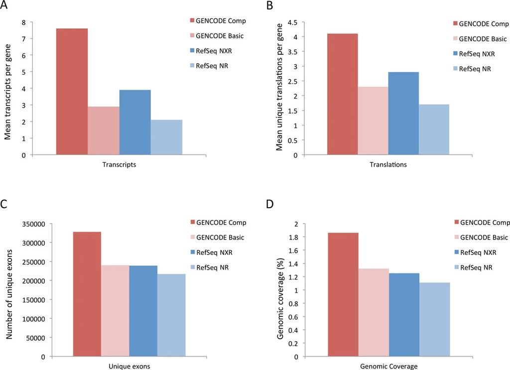

### 1.2. Aims

What we will do with this dataset:

1. Be familiar with gene annotation modality.
2. Tidy data and create a table for your analysis.
3. Apply tidyverse functions for data munging.

Please note that there is better solution for getting gene annotation in R if you use a biomart. Our tutorial is only designed to have a practice on tidyverse exercise.

## 2. Explore your data

### 2.1. Unboxing your dataset

This tutorial will use a gene annotation file from the GENCODE. You will need to download the file from the GENCODE. If you are using terminal, please download file using wget:

```r
# Run from your terminal, not R console
# wget ftp://ftp.ebi.ac.uk/pub/databases/gencode/Gencode_human/release_31/gencode.v31.basic.annotation.gtf.gz

# Once you downloaded the file, you won't need to download it again. So please comment out the command above by adding #
```

Once you download the file, you can print out the first few lines using the following bash command (we will learn UNIX commands later):

```r
# Run from your terminal, not R console
# gzcat gencode.v31.basic.annotation.gtf.gz | head -7
```

The file is the GFT file format, which you will find most commonly in gene annotation. Please read the file format thoroughly in the link above. For the tutorial, we need to load two packages. If the package is not installed in your system, please install it.

1. tidyverse, a package you have learnt from the chapter 5.
2. readr, a package provides a fast and friendly way to read. Since the file gencode.v31.basic.annotation.gtf.gz is pretty large, you will need some function to load data quickly into your workspace. readr in a part of tidyverse, so you can just load tidyverse to use readr functions.

Let’s load the GTF file into your workspace. We will use read_delim function from the readr package. This is much faster loading than read.delim or read.csv from R base. However, please keep in mind that some parameters and output class for read_delim are slightly different from them.

```r
library(tidyverse)
d = read_delim('gencode.v31.annotation.gtf', delim = '/t', skip = 5, progress = F,col_names = F)
```

```r
if (!requireNamespace("BiocManager", quietly = TRUE))
    install.packages("BiocManager")

BiocManager::install("rtracklayer")
d = rtracklayer::import('gencode.v31.annotation.gtf')
class(d)
```

```
## [1] "GRanges"
## attr(,"package")
## [1] "GenomicRanges"
```

You will find out that this is GRanges class. This is from the package Genomic Range, specifically dealing with genomic datasets but we are not heading into this in this tutorial. So please find this information if you are serious on this. We are converting d into a data frame as following:

```r
d = d %>% as.data.frame()
```

Let’s overview few lines from the data frame, and explore what you get in this object.

```r
head(d)
```

|  | seqnames | start | end | width | strand | source | type | score | phase | gene_id | gene_type | gene_name | level | hgnc_id | havana_gene | transcript_id | transcript_type | transcript_name | transcript_support_level | tag | havana_transcript | exon_number | exon_id | ont | protein_id | ccdsid |
| --- | --- | --- | --- | --- | --- | --- | --- | --- | --- | --- | --- | --- | --- | --- | --- | --- | --- | --- | --- | --- | --- | --- | --- | --- | --- | --- |
| 1 | chr1 | 11869 | 14409 | 2541 | + | HAVANA | gene | NA | NA | ENSG00000223972.5 | transcribed_unprocessed_pseudogene | DDX11L1 | 2 | HGNC:37102 | OTTHUMG00000000961.2 | NA | NA | NA | NA | NA | NA | NA | NA | NA | NA | NA |
| 2 | chr1 | 11869 | 14409 | 2541 | + | HAVANA | transcript | NA | NA | ENSG00000223972.5 | transcribed_unprocessed_pseudogene | DDX11L1 | 2 | HGNC:37102 | OTTHUMG00000000961.2 | ENST00000456328.2 | lncRNA | DDX11L1-202 | 1 | basic | OTTHUMT00000362751.1 | NA | NA | NA | NA | NA |
| 3 | chr1 | 11869 | 12227 | 359 | + | HAVANA | exon | NA | NA | ENSG00000223972.5 | transcribed_unprocessed_pseudogene | DDX11L1 | 2 | HGNC:37102 | OTTHUMG00000000961.2 | ENST00000456328.2 | lncRNA | DDX11L1-202 | 1 | basic | OTTHUMT00000362751.1 | 1 | ENSE00002234944.1 | NA | NA | NA |
| 4 | chr1 | 12613 | 12721 | 109 | + | HAVANA | exon | NA | NA | ENSG00000223972.5 | transcribed_unprocessed_pseudogene | DDX11L1 | 2 | HGNC:37102 | OTTHUMG00000000961.2 | ENST00000456328.2 | lncRNA | DDX11L1-202 | 1 | basic | OTTHUMT00000362751.1 | 2 | ENSE00003582793.1 | NA | NA | NA |
| 5 | chr1 | 13221 | 14409 | 1189 | + | HAVANA | exon | NA | NA | ENSG00000223972.5 | transcribed_unprocessed_pseudogene | DDX11L1 | 2 | HGNC:37102 | OTTHUMG00000000961.2 | ENST00000456328.2 | lncRNA | DDX11L1-202 | 1 | basic | OTTHUMT00000362751.1 | 3 | ENSE00002312635.1 | NA | NA | NA |
| 6 | chr1 | 12010 | 13670 | 1661 | + | HAVANA | transcript | NA | NA | ENSG00000223972.5 | transcribed_unprocessed_pseudogene | DDX11L1 | 2 | HGNC:37102 | OTTHUMG00000000961.2 | ENST00000450305.2 | transcribed_unprocessed_pseudogene | DDX11L1-201 | NA | basic | OTTHUMT00000002844.2 | NA | NA | PGO:0000019 | NA | NA |